# Variable Importance vs p-values in Model Selection

C.M. Gienger

## Question

**In model selection, why do we need to calculate variable importance weights rather than using variable p-values from the full (global) model?**

## Answer

This gets at the philosophy of **information-theoretic model selection** versus **null-hypothesis significance testing (NHST)**.

#### 1. P-values are conditional on the *full/global model*

- A p-value for a variable is calculated assuming the *global model* (with all predictors included) is the “true” structure.
- This means the p-value tells you about that variable’s contribution **only in the context of all the other predictors being present**.
- If predictors are correlated (multicollinearity), or if the global model includes weak/unnecessary terms, p-values can fluctuate wildly.
- Thus, p-values don’t reflect how consistently a variable improves model fit across *alternative plausible models*.

#### 2. Model selection is about *relative support* across models

- Information-theoretic approaches (AIC, AICc, BIC, etc.) recognize that there is rarely one single “true” model. Instead, we compare candidate models for their relative support from the data.
- **Variable importance weights** (e.g., `MuMIn::sw`) summarize how often a variable appears in the set of best-supported models, weighted by each model’s Akaike weight.
- This tells you: *Across all plausible models, how important is this variable in explaining variation?*

#### 3. Importance weights account for *model uncertainty*

- P-values from a global model **ignore model uncertainty** — they pretend the global model is correct.
- Variable importance weights explicitly incorporate the possibility that multiple models explain the data nearly equally well.
- This is especially critical in ecology and wildlife biology, where many predictors are correlated and no single model dominates.

#### 4. Interpretation differences

- **P-value**: “If the global model is true, what is the probability of observing this effect (or more extreme) by chance?”
- **Importance weight**: “Given the evidence across all models, how likely is it that this variable truly belongs in the model?”

### Bottom line

We calculate variable importance weights instead of relying on p-values because **p-values depend on one arbitrary model (the global one), whereas importance weights integrate over the whole model set and thus better capture model uncertainty and predictor relevance**.

## Compare P-values to Variable Importance Weights - Elk Habitat Selection Revisted

```r
# Load packages
library(MuMIn)    # for model selection & importance weights
library(ggplot2)
library(patchwork)

options(width = 90)  #adjust width of console outout to allow wide tables to fit

#import data
data_elk<-read.csv("../data/elk_example.csv")

# Fit a global model model with all parameters
all.parms <- lm(density ~ slope + distance + elev + pct.cover, data = data_elk)

# Look at p-values from the global model
summary(all.parms)
```

```
##
## Call:
## lm(formula = density ~ slope + distance + elev + pct.cover, data = data_elk)
##
## Residuals:
##        Min         1Q     Median         3Q        Max
## -0.0166379 -0.0069336 -0.0001803  0.0059001  0.0256340
##
## Coefficients:
##               Estimate Std. Error t value Pr(>|t|)
## (Intercept) -1.436e-02  2.592e-03  -5.540 7.67e-08 ***
## slope       -1.187e-02  4.060e-02  -0.292  0.77029
## distance     5.162e-05  5.248e-06   9.837  < 2e-16 ***
## elev         2.044e-05  7.261e-06   2.815  0.00527 **
## pct.cover    2.377e-05  2.291e-05   1.037  0.30061
## ---
## Signif. codes:  0 '***' 0.001 '**' 0.01 '*' 0.05 '.' 0.1 ' ' 1
##
## Residual standard error: 0.008236 on 250 degrees of freedom
## Multiple R-squared:  0.3136, Adjusted R-squared:  0.3026
## F-statistic: 28.55 on 4 and 250 DF,  p-value: < 2.2e-16
```

If you only looked at these p-values, you might conclude that `slope` and `pct.cover` don’t matter much.

Model Selection and Variable Importance

```r
# Dredge through all subsets of the global model
options(na.action = "na.fail")  # required for dredge
results <- dredge(all.parms)
```

```
## Fixed term is "(Intercept)"
```

```r
results
```

```
## Global model call: lm(formula = density ~ slope + distance + elev + pct.cover, data = data_elk)
## ---
## Model selection table
##        (Int)       dst       elv   pct.cvr      slp df  logLik    AICc delta weight
## 4  -0.013280 5.195e-05 1.832e-05                     4 863.907 -1719.7  0.00  0.448
## 8  -0.014560 5.177e-05 1.860e-05 2.362e-05           5 864.448 -1718.7  1.00  0.272
## 12 -0.013080 5.181e-05 2.002e-05           -0.01096  5 863.944 -1717.6  2.01  0.164
## 16 -0.014360 5.162e-05 2.044e-05 2.377e-05 -0.01187  6 864.491 -1716.6  3.01  0.100
## 10 -0.012920 5.207e-05                      0.08634  4 860.130 -1712.1  7.55  0.010
## 14 -0.014000 5.191e-05           2.015e-05  0.08731  5 860.512 -1710.8  8.87  0.005
## 2  -0.006235 4.824e-05                               3 851.388 -1696.7 22.97  0.000
## 6  -0.006971 4.809e-05           1.474e-05           4 851.579 -1695.0 24.65  0.000
## 3   0.004224           1.331e-05                     3 821.497 -1636.9 82.76  0.000
## 7   0.002455           1.370e-05 3.106e-05           4 822.168 -1636.2 83.48  0.000
## 11  0.004913           2.128e-05           -0.05103  4 822.079 -1636.0 83.66  0.000
## 15  0.003126           2.184e-05 3.159e-05 -0.05204  5 822.777 -1635.3 84.34  0.000
## 9   0.005179                                0.05226  3 818.964 -1631.8 87.82  0.000
## 13  0.003614                     2.777e-05  0.05374  4 819.492 -1630.8 88.83  0.000
## 1   0.008517                                         2 816.516 -1629.0 90.67  0.000
## 5   0.007247                     2.399e-05           3 816.903 -1627.7 91.94  0.000
## Models ranked by AICc(x)
```

**Comparing p-values vs Importance Weights**

```r
# variable importance weights
sw(results)
```

```
##                      distance elev pct.cover slope
## Sum of weights:      1.00     0.98 0.38      0.28
## N containing models:    8        8    8         8
```

```r
#p-values from global model
p_list
```

```
## $slope
## [1] 0.77
##
## $distance
## [1] 0
##
## $elev
## [1] 0.005
##
## $pct.cover
## [1] 0.301
```

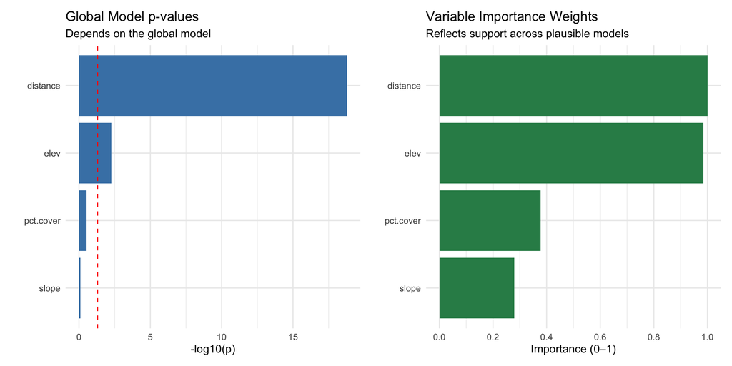

We can compare the magnitude of p-values against Variable Importance. We use −log₁₀(p) to display the magnitude of a p-value because it makes very small probabilities easier to interpret, compare, and visualize. Larger values = lower p-values; red dotted line is p=0.05 threshold.

**Conclusion**

- Global model p-values depend heavily on the assumed model and ignore model uncertainty.
- Variable importance weights reflect how consistently a variable improves fit across the *set* of plausible models.
- For model selection, importance weights provide a more reliable measure of predictor relevance.